# Praktikum Pertemuan 5

Uiwang Nur Thoriq

2023-09-21

```r
library(ggplot2)
library(tsibble)
library(tseries)
library(MASS)
library(rio)
datampdw <- import("https://raw.githubusercontent.com/UiwangNT/Praktikum_MPDW/main/data/US_inflation_rates_csv.csv")
datampdw.ts<-ts(datampdw[,3])
datampdw.ts
```

```
## Time Series:
## Start = 1
## End = 918
## Frequency = 1
##   [1]  21.480  21.620  22.000  22.000  21.950  22.080  22.230  22.400  22.840
##  [10]  22.910  23.060  23.410  23.680  23.670  23.500  23.820  24.010  24.150
##  [19]  24.400  24.430  24.360  24.310  24.160  24.050  24.010  23.910  23.910
##  [28]  23.920  23.910  23.920  23.700  23.700  23.750  23.670  23.700  23.610
##  [37]  23.510  23.610  23.640  23.650  23.770  23.880  24.070  24.200  24.340
##  [46]  24.500  24.600  24.980  25.380  25.830  25.880  25.920  25.990  25.930
##  [55]  25.910  25.860  26.030  26.160  26.320  26.470  26.450  26.410  26.390
##  [64]  26.460  26.470  26.530  26.680  26.690  26.630  26.690  26.690  26.710
##  [73]  26.640  26.590  26.630  26.690  26.700  26.770  26.790  26.850  26.890
##  [82]  26.950  26.850  26.870  26.940  26.990  26.930  26.860  26.930  26.940
##  [91]  26.860  26.850  26.810  26.720  26.780  26.770  26.770  26.820  26.790
```

[output cut: 91 more lines]

## Plot Time Series Data Penuh

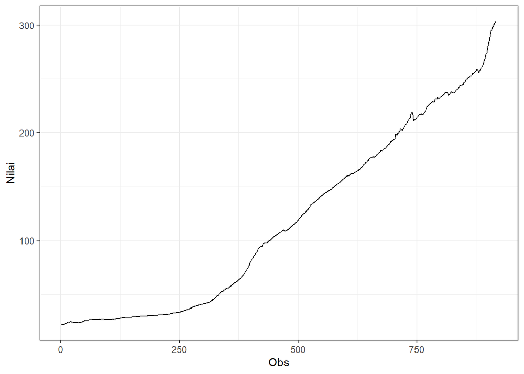

```r
plot <- datampdw.ts |> as_tsibble() |>
  ggplot(aes(x = index, y = value)) + geom_line() + theme_bw() +
  xlab("Obs") + ylab("Nilai")
plot
```

```r
mean(datampdw.ts)
```

```
## [1] 117.7948
```

```r
var(datampdw.ts)
```

```
## [1] 7011.778
```

Berdasarkan plot time series, sangat jelas bahwa data tidak stasioner baik pada ragam maupun rataan. Data memiliki pola trend.

## Plot ACF Data Penuh

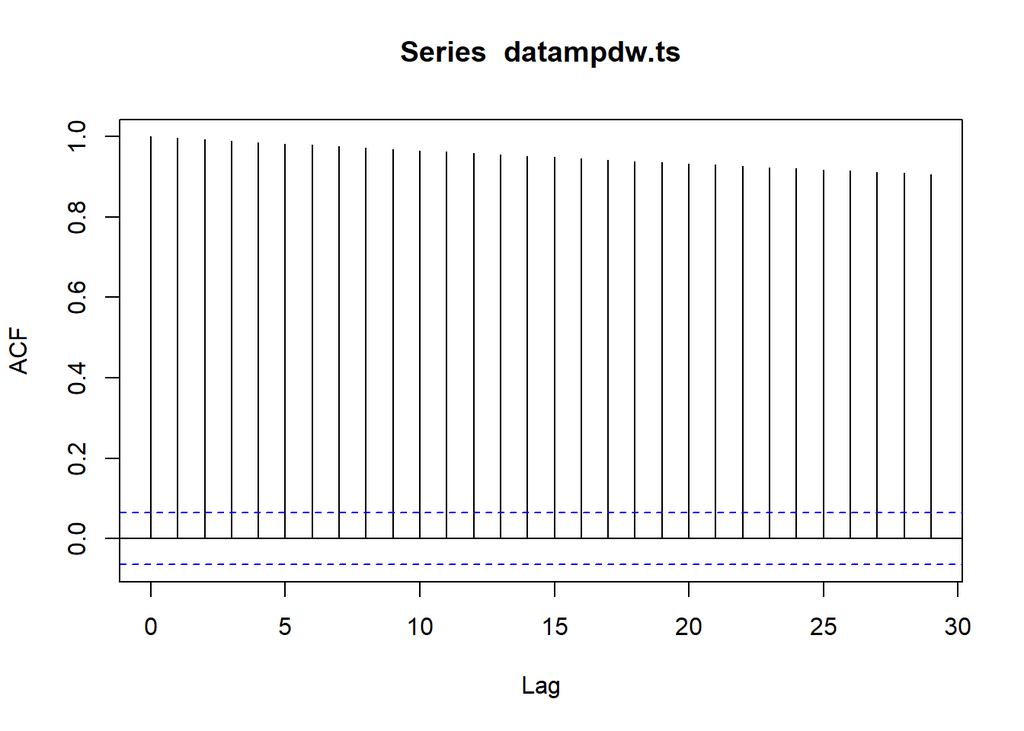

```r
acf(datampdw.ts)
```

Berdasarkan plot ACF terlihat bahwa data cenderung *tails off* dan turun perlahan.

## Uji ADF Data Penuh

```r
tseries::adf.test(datampdw.ts)
```

```
##
##  Augmented Dickey-Fuller Test
##
## data:  datampdw.ts
## Dickey-Fuller = -1.0781, Lag order = 9, p-value = 0.9261
## alternative hypothesis: stationary
```

Didapatkan nilai $p_{value}$ sebesar 0.9261 > 0.05. Maka dapat disimpulkan bahwa data tidak stasioner pada rataan.

## Plot Boxcox Data Penuh

```r
index <- seq(1:length(datampdw.ts))
bc = boxcox(datampdw.ts~index, lambda = seq(-2,2,by=0.01))
```

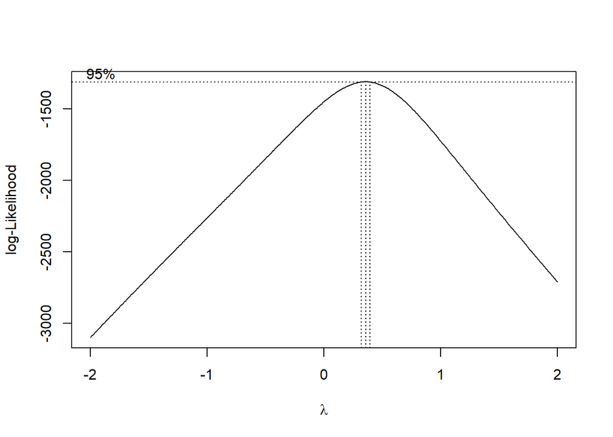

```r
lambda <- bc$x[which.max(bc$y)]
lambda
```

```
## [1] 0.36
```

```r
bc$x[bc$y > max(bc$y) - 1/2 * qchisq(.95,1)]
```

```
## [1] 0.32 0.33 0.34 0.35 0.36 0.37 0.38 0.39
```

Pada box-cox didapatkan nilai $\lambda$ optimum sebesar *0.36* dan pada selang kepercayaan 95% nilai memiliki batas bawah *0.32* dan batas atas *0.39*. Selang tidak memuat nilai 1. Maka dapat disimpulkan data tidak stasioner dalam ragam.

## Partisi 1

```r
part.1 <- datampdw.ts[1:250] |> ts()
part.1
```

```
## Time Series:
## Start = 1
## End = 250
## Frequency = 1
##   [1] 21.48 21.62 22.00 22.00 21.95 22.08 22.23 22.40 22.84 22.91 23.06 23.41
##  [13] 23.68 23.67 23.50 23.82 24.01 24.15 24.40 24.43 24.36 24.31 24.16 24.05
##  [25] 24.01 23.91 23.91 23.92 23.91 23.92 23.70 23.70 23.75 23.67 23.70 23.61
##  [37] 23.51 23.61 23.64 23.65 23.77 23.88 24.07 24.20 24.34 24.50 24.60 24.98
##  [49] 25.38 25.83 25.88 25.92 25.99 25.93 25.91 25.86 26.03 26.16 26.32 26.47
##  [61] 26.45 26.41 26.39 26.46 26.47 26.53 26.68 26.69 26.63 26.69 26.69 26.71
##  [73] 26.64 26.59 26.63 26.69 26.70 26.77 26.79 26.85 26.89 26.95 26.85 26.87
##  [85] 26.94 26.99 26.93 26.86 26.93 26.94 26.86 26.85 26.81 26.72 26.78 26.77
##  [97] 26.77 26.82 26.79 26.79 26.77 26.71 26.76 26.72 26.85 26.82 26.88 26.87
## [109] 26.83 26.86 26.89 26.93 27.03 27.15 27.29 27.31 27.35 27.51 27.51 27.63
## [121] 27.67 27.80 27.86 27.93 28.00 28.11 28.19 28.28 28.32 28.32 28.41 28.47
## [133] 28.64 28.70 28.87 28.94 28.94 28.91 28.89 28.94 28.91 28.91 28.95 28.97
## [145] 29.01 29.00 28.97 28.98 29.04 29.11 29.15 29.18 29.25 29.35 29.35 29.41
## [157] 29.37 29.41 29.41 29.54 29.57 29.61 29.55 29.61 29.61 29.75 29.78 29.81
## [169] 29.84 29.84 29.84 29.81 29.84 29.84 29.92 29.94 29.98 29.98 29.98 30.01
## [181] 30.04 30.11 30.17 30.21 30.24 30.21 30.22 30.28 30.42 30.38 30.38 30.38
## [193] 30.44 30.48 30.51 30.48 30.51 30.61 30.69 30.75 30.72 30.75 30.78 30.88
## [205] 30.94 30.91 30.94 30.95 30.98 31.01 31.02 31.05 31.08 31.12 31.21 31.25
## [217] 31.28 31.28 31.31 31.38 31.48 31.61 31.58 31.55 31.62 31.65 31.75 31.85
## [229] 31.88 32.08 32.18 32.28 32.35 32.38 32.45 32.65 32.75 32.85 32.88 32.92
## [241] 32.90 33.00 33.00 33.10 33.10 33.30 33.40 33.50 33.60 33.70
```

### Plot Time Series Data Partisi 1

```r
mean(part.1)
```

```
## [1] 28.01664
```

```r
var(part.1)
```

```
## [1] 8.580864
```

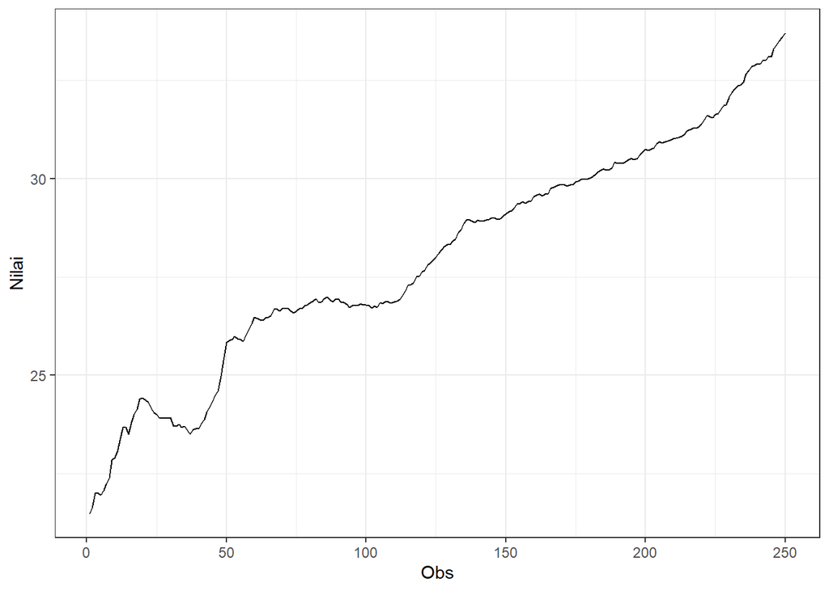

```r
part.1 |> as_tsibble() |>
  ggplot(aes(x = index, y = value)) +
  geom_line() + theme_bw() +
  xlab("Obs") + ylab("Nilai")
```

Berdasarkan plot time series, data partisi satu tidak stasioner pada rataan maupun ragam.

### Plot ACF Data Partisi 1

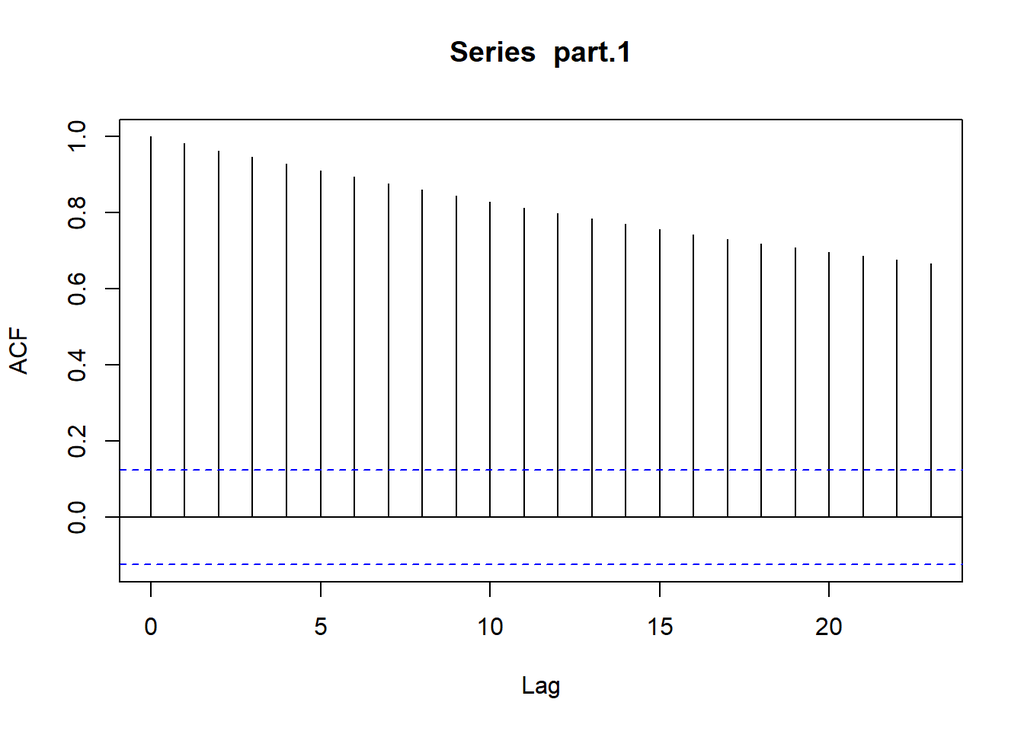

```r
acf(part.1)
```

Data cenderung *tails off* dengan pola yang turun perlahan.

### Uji ADF Data Partisi 1

```r
tseries::adf.test(part.1)
```

```
##
##  Augmented Dickey-Fuller Test
##
## data:  part.1
## Dickey-Fuller = -3.6245, Lag order = 6, p-value = 0.03132
## alternative hypothesis: stationary
```

Berdasarkan uji ADF, didapat *p-value* sebesar 0.03132 < 5% sehingga menandakan bahwa data stasioner dalam rataan.

### Plot Boxcox Data Partisi 1

```r
index <- seq(1:length(part.1))
bc = boxcox(part.1~index, lambda = seq(-6,6,by=0.01))
```

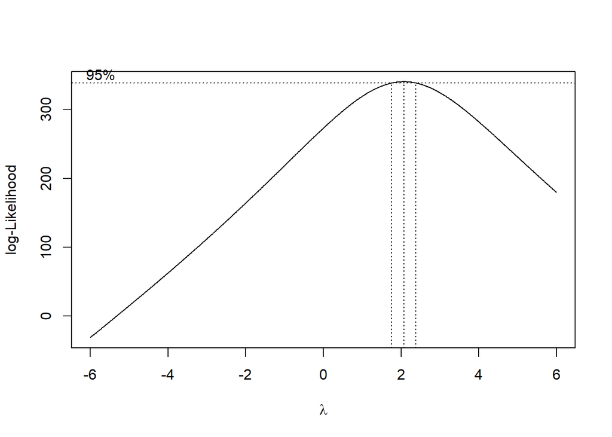

```r
lambda <- bc$x[which.max(bc$y)]
lambda
```

```
## [1] 2.07
```

```r
bc$x[bc$y > max(bc$y) - 1/2 * qchisq(.95,1)]
```

```
##  [1] 1.76 1.77 1.78 1.79 1.80 1.81 1.82 1.83 1.84 1.85 1.86 1.87 1.88 1.89 1.90
## [16] 1.91 1.92 1.93 1.94 1.95 1.96 1.97 1.98 1.99 2.00 2.01 2.02 2.03 2.04 2.05
## [31] 2.06 2.07 2.08 2.09 2.10 2.11 2.12 2.13 2.14 2.15 2.16 2.17 2.18 2.19 2.20
## [46] 2.21 2.22 2.23 2.24 2.25 2.26 2.27 2.28 2.29 2.30 2.31 2.32 2.33 2.34 2.35
## [61] 2.36 2.37 2.38
```

Pada box-cox didapatkan nilai $\lambda$ optimum sebesar *2.07* dan pada selang kepercayaan 95% nilai memiliki batas bawah *1.76* dan batas atas *2.38*. Selang tidak memuat nilai 1. Maka dapat disimpulkan data tidak stasioner dalam ragam.

## Partisi 2

```r
part.2 <- datampdw.ts[1:500] |> ts()
part.2
```

```
## Time Series:
## Start = 1
## End = 500
## Frequency = 1
##   [1]  21.48  21.62  22.00  22.00  21.95  22.08  22.23  22.40  22.84  22.91
##  [11]  23.06  23.41  23.68  23.67  23.50  23.82  24.01  24.15  24.40  24.43
##  [21]  24.36  24.31  24.16  24.05  24.01  23.91  23.91  23.92  23.91  23.92
##  [31]  23.70  23.70  23.75  23.67  23.70  23.61  23.51  23.61  23.64  23.65
##  [41]  23.77  23.88  24.07  24.20  24.34  24.50  24.60  24.98  25.38  25.83
##  [51]  25.88  25.92  25.99  25.93  25.91  25.86  26.03  26.16  26.32  26.47
##  [61]  26.45  26.41  26.39  26.46  26.47  26.53  26.68  26.69  26.63  26.69
##  [71]  26.69  26.71  26.64  26.59  26.63  26.69  26.70  26.77  26.79  26.85
##  [81]  26.89  26.95  26.85  26.87  26.94  26.99  26.93  26.86  26.93  26.94
##  [91]  26.86  26.85  26.81  26.72  26.78  26.77  26.77  26.82  26.79  26.79
## [101]  26.77  26.71  26.76  26.72  26.85  26.82  26.88  26.87  26.83  26.86
```

[output cut: 39 more lines]

### Plot Time Series Data Partisi 2

```r
mean(part.2)
```

```
## [1] 49.61772
```

```r
var(part.2)
```

```
## [1] 869.8402
```

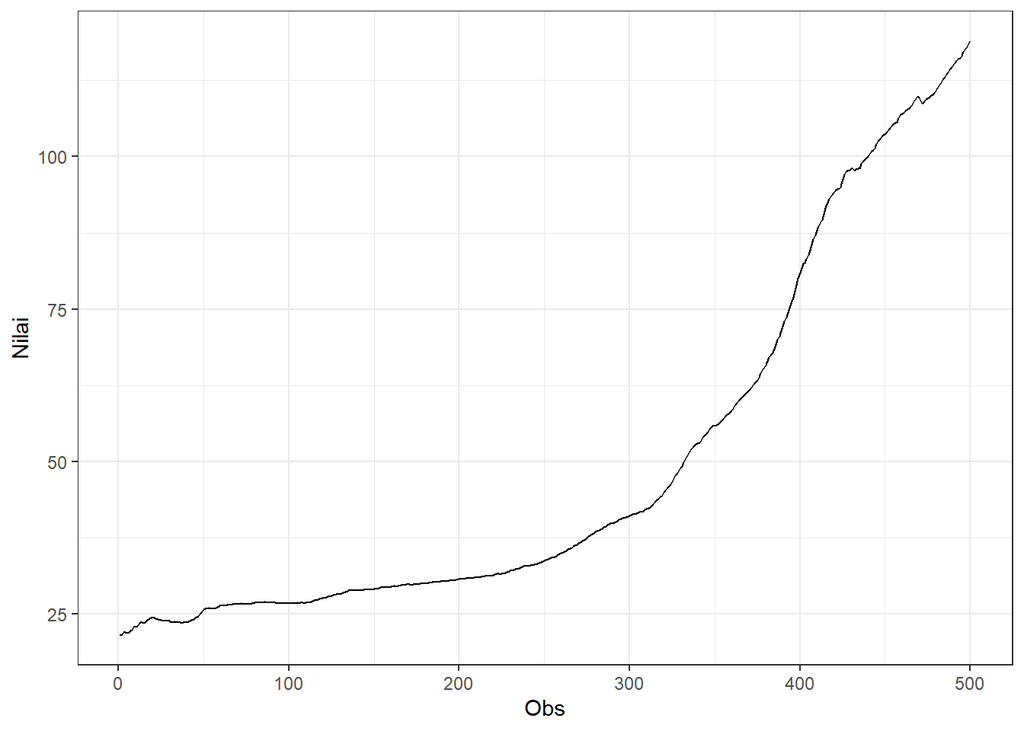

```r
part.2 |> as_tsibble() |>
  ggplot(aes(x = index, y = value)) +
  geom_line() + theme_bw() +
  xlab("Obs") + ylab("Nilai")
```

Berdasarkan plot time series, data partisi dua tidak stasioner pada rataan maupun ragam.

### Plot ACF Data Partisi 2

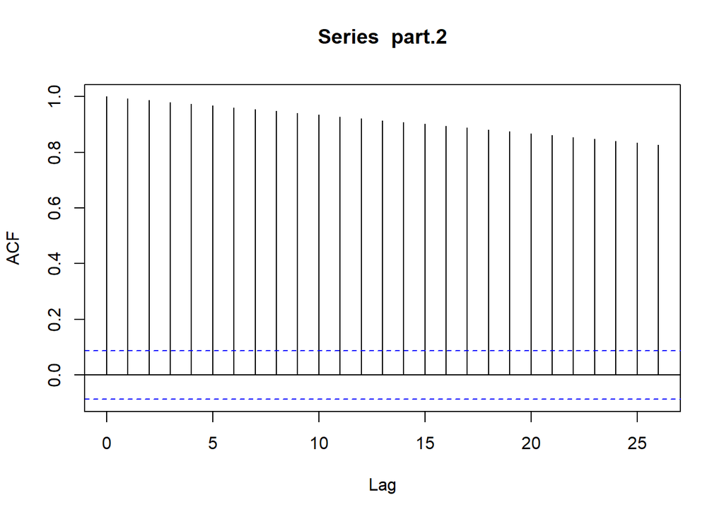

```r
acf(part.2)
```

Data cenderung *tails off* dengan pola yang turun perlahan.

### Uji ADF Data Partisi 2

```r
tseries::adf.test(part.2)
```

```
##
##  Augmented Dickey-Fuller Test
##
## data:  part.2
## Dickey-Fuller = -0.42816, Lag order = 7, p-value = 0.9851
## alternative hypothesis: stationary
```

Berdasarkan uji ADF, didapat *p-value* sebesar 0.9851 > 5% sehingga menandakan bahwa data tidak stasioner dalam rataan.

### Plot Boxcox Data Partisi 2

```r
index <- seq(1:length(part.2))
bc = boxcox(part.2~index, lambda = seq(-2,0,by=0.01))
```

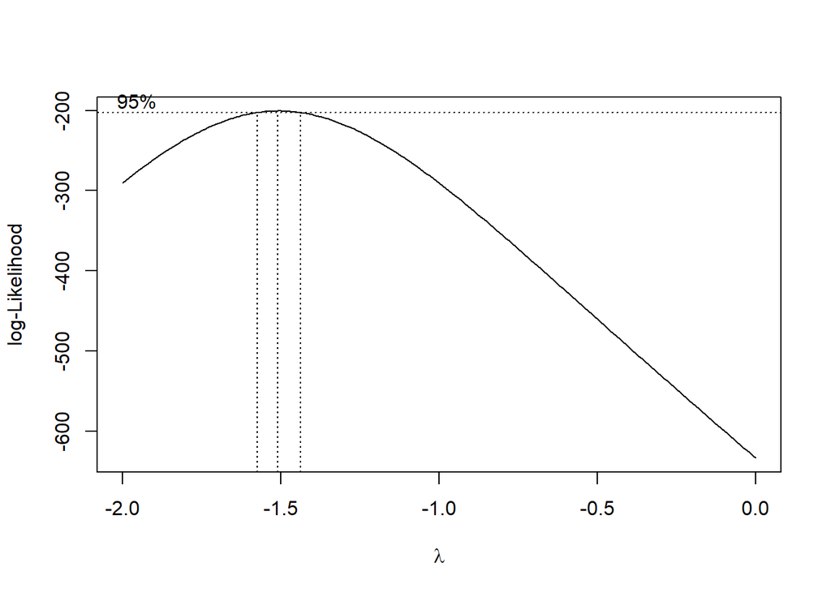

```r
lambda <- bc$x[which.max(bc$y)]
lambda
```

```
## [1] -1.51
```

```r
bc$x[bc$y > max(bc$y) - 1/2 * qchisq(.95,1)]
```

```
##  [1] -1.57 -1.56 -1.55 -1.54 -1.53 -1.52 -1.51 -1.50 -1.49 -1.48 -1.47 -1.46
## [13] -1.45 -1.44
```

Pada box-cox didapatkan nilai $\lambda$ optimum sebesar *-1.51* dan pada selang kepercayaan 95% nilai memiliki batas bawah *-1.57* dan batas atas *-1.44*. Selang tidak memuat nilai 1. Maka dapat disimpulkan data tidak stasioner dalam ragam.